# Introduction

17 February 2017, University of York

## Me

### Macroecologist

### Quality assurance

[figure not shown]

### Stock control

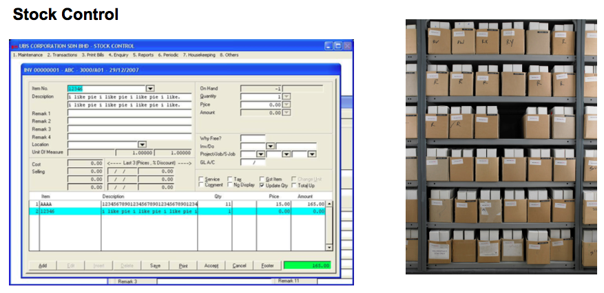

## Progress in Science

## pitfalls

[figure not shown]

## RDM at postgraduate level

> [@tomjwebb](https://twitter.com/tomjwebb) "Remember what you did in your Master program? Yeah? Well, don't do that anymore."

> — Nate Hough-Snee (@NHoughSnee) [January 16, 2015](https://twitter.com/NHoughSnee/status/556235794466082816)

> Act as though every short term study will become a long term one [@tomjwebb](https://twitter.com/tomjwebb). Needs to be reproducible in 3, 20, 100 yrs

> — oceans initiative (@oceansresearch) [January 16, 2015](https://twitter.com/oceansresearch/status/556107891610894337)

## Plan your RDM

- **Start early**. Make an RMD plan before collecting data.
- Anticipate **data products** as part of your thesis **outputs**
- Think about what technologies to use

### **Take initiative. You are now responsible:**

[figure not shown]

### **seek help from support teams**

Most university libraries have assistants dedicated to RDM:

> [@tomjwebb](https://twitter.com/tomjwebb) [@ScientificData](https://twitter.com/ScientificData) Talk to their librarian for data management strategies [#datainfolit](https://twitter.com/hashtag/datainfolit?src=hash)

> — Yasmeen Shorish (@yasmeen_azadi) [January 16, 2015](https://twitter.com/yasmeen_azadi/status/556129700129800192)

## Data collection

- if you're going to record data manually, produce data entry sheets or tables. Design them with data digitisation in mind
- if you are doing fieldwork consider using a pencil!
- think in good time about variable definitions and naming

> [@tomjwebb](https://twitter.com/tomjwebb) at minimum conform units, data fields to existing public databases, traits=TRY, collections=DarwinCore, plots=SALVIASVegBank

> — Brian J. Enquist (@bjenquist) [January 16, 2015](https://twitter.com/bjenquist/status/556122032123826177)

## Data entering

### an extreme but in many ways defendable approach

> [@tomjwebb](https://twitter.com/tomjwebb) stay away from excel at all costs?

> — Timothée Poisot (@tpoi) [January 16, 2015](https://twitter.com/tpoi/status/556107000950829056)

## excel

> [@tomjwebb](https://twitter.com/tomjwebb) [@tpoi](https://twitter.com/tpoi) excel is fine for data entry. Just save in plain text format like csv. Some additional tips: [pic.twitter.com/8fUv9PyVjC](https://t.co/8fUv9PyVjC)

> — Jaime Ashander (@jaimedash) [January 16, 2015](https://twitter.com/jaimedash/status/556113131932381185)

> [@jaimedash](https://twitter.com/jaimedash) just don’t let excel anywhere near dates or times. [@tomjwebb](https://twitter.com/tomjwebb) [@tpoi](https://twitter.com/tpoi) [@larysar](https://twitter.com/larysar)

> — Dave Harris (@davidjayharris) [January 16, 2015](https://twitter.com/davidjayharris/status/556126474550263809)

## spreadsheet advice

> God bless the UK Gov’t Statistical Service Good Practice Team. Sane spreadsheet advice. https://t.co/MLQMvnBzkV [pic.twitter.com/OD7GzfVKLW](http://t.co/OD7GzfVKLW)

> — Jenny Bryan (@JennyBryan) [November 27, 2014](https://twitter.com/JennyBryan/status/538013071826898944)

## databases

> [@tomjwebb](https://twitter.com/tomjwebb) databases? [@swcarpentry](https://twitter.com/swcarpentry) has a good course on SQLite

> — Timothée Poisot (@tpoi) [January 16, 2015](https://twitter.com/tpoi/status/556142573308608513)

> [@tomjwebb](https://twitter.com/tomjwebb) [@tpoi](https://twitter.com/tpoi) if the data are moderately complex, or involve multiple people, best to set up a database with well designed entry form 1/2

> — Luca Borger (@lucaborger) [January 16, 2015](https://twitter.com/lucaborger/status/556226732496535552)

> [@tomjwebb](https://twitter.com/tomjwebb) Entering via a database management system (e.g., Access, Filemaker) can make entry easier & help prevent data entry errors [@tpoi](https://twitter.com/tpoi)

> — Ethan White (@ethanwhite) [January 16, 2015](https://twitter.com/ethanwhite/status/556119480493813760)

> [@tomjwebb](https://twitter.com/tomjwebb) it also prevents a lot of different bad practices. It is possible to do some of this in Excel. [@tpoi](https://twitter.com/tpoi)

> — Ethan White (@ethanwhite) [January 16, 2015](https://twitter.com/ethanwhite/status/556119826582605824)

> [@ethanwhite](https://twitter.com/ethanwhite) +1 Enforcing data types, options from selection etc, just some useful things a DB gives you, if you turn them on [@tomjwebb](https://twitter.com/tomjwebb) [@tpoi](https://twitter.com/tpoi)

> — Gavin Simpson (@ucfagls) [January 16, 2015](https://twitter.com/ucfagls/status/556120176748290048)

## data carpentry

http://www.datacarpentry.org/lessons/

[figure not shown]

## Then record…everything!

#### Even details that seem insignificant may prove vital to your research, or to interoperability with others' work:

> [@tomjwebb](https://twitter.com/tomjwebb) record every detail about how/where/why it is collected

> — Sal Keith (@Sal_Keith) [January 16, 2015](https://twitter.com/Sal_Keith/status/556110605053349888)

## Raw data are sacrosanct

> [@tomjwebb](https://twitter.com/tomjwebb) don't, not even with a barge pole, not for one second, touch or otherwise edit the raw data files. Do any manipulations in script

> — Gavin Simpson (@ucfagls) [January 16, 2015](https://twitter.com/ucfagls/status/556107371634634755)

> [@tomjwebb](https://twitter.com/tomjwebb) [@srsupp](https://twitter.com/srsupp) Keep one or a few good master data files (per data collection of interest), and code your formatting with good annotation.

> — Desiree Narango (@DLNarango) [January 16, 2015](https://twitter.com/DLNarango/status/556128407445323778)

## Avoid catastrophy

> [@tomjwebb](https://twitter.com/tomjwebb) Back it up

> — Ben Bond-Lamberty (@BenBondLamberty) [January 16, 2015](https://twitter.com/BenBondLamberty/status/556120946722222080)

## General tips

## Data formats

- Text files are the most general file format
- csv files most common

> [@tomjwebb](https://twitter.com/tomjwebb) It has to be interoperability/openness - can I read your data with whatever I use, without having to convert it?

> — Paul Swaddle (@paul_swaddle) [January 16, 2015](https://twitter.com/paul_swaddle/status/556148166270406656)

## File naming

#### **Give files descriptive, consistent names**, e.g. “AK_IUCNDataExtraction_20131002.csv”

#### **Make it machine readable**

## Use good null values

### Missing values are a fact of life

- Usually, best solution is to **leave blank**
- **`NA`** or **`NULL`** are also good options
- **NEVER use `0`**. Avoid numbers like **`-999`**
- Don’t make up your own code for missing values

## data checks through [**`read.csv()`**](http://stat.ethz.ch/R-manual/R-devel/library/utils/html/read.table.html)

- **`na.string`:** character vector of values to be coded missing and replaced with `NA` to argument eg
- **`strip.white`:** Logical. if `TRUE` strips leading and trailing white space from unquoted character fields
- **`blank.lines.skip`:** Logical: if `TRUE` blank lines in the input are ignored.
- **`fileEncoding`:** if you're getting funny characters, you probably need to specify the correct encoding.

```r
read.csv(file, na.strings = c("NA", "-999"), strip.white = TRUE,
         blank.lines.skip = TRUE, fileEncoding = "mac")
```

## Make your data alignable and generalisable

What information would other users require to combine their your data with their's?

- Time `time`
- space `geography (lat, lon)`
- taxonomy `species name; authority / source`
- provide information on extent and resolution
- include some simple QA tests (eg. number of dimensions, sum of numeric columns etc)
- Before publishing consider writing some simple tests.